# Using the Events System

In the event system, we use events that happen in sequence. Events are *Animations* and can use the *Call Method Track* to execute methods within events. We can change exported variables within events too.

By calling `play_current_event()` on the *EventsPlayer*, we execute an event and iterate the current event. When we call this method again, it plays the next event in the list. We order events with alpha-numeric indexing characters, so `03-tough-enemy` plays after `00-wave-1`.

That said, we use these events in a per level manner. Each level should have its own set of events. Before we create an inherited scene using the `res://Levels/Level.tscn` as base, we need to erase its events. As it’s going to be our level template, it shouldn’t have any animations. Remember, this can cause some issues on inherited scenes because we may work with shared resources.

Open the `Level.tscn` and remove all the events in the *EventsPlayer*.

Let’s make a basic dialogue system to introduce players to our game’s world and provide some context. This dialogue system has no branching capability, so we use the *EventsPlayer* itself to change dialogue lines and move through the dialogue.

Let’s make a nice interface using a new *CanvasLayer* node as child of the *Level*. Rename it to *UIDialogueLayer*. We need to move this layer on top of the one in the *Game > UI* because we have interface elements that the player should interact with. Set its *Layer* property to `2` to put it above the *MouseBarrier*, allowing players to interact with its elements even in play mode.

Add a *Panel* as child of the *UIDialogueLayer*. Rename it as *UIDialoguePanel* and change its layout to *Center Bottom*.

To display our dialogue lines, add a *Label* as a child of the *UIDialoguePanel*. Change the *Label > Align* and *Valign* to *Center* and toggle on the *Autowrap* property.

Add a *Button* as child of the *UIDialoguePanel*. Players will use this to jump to the next event. We connect the *Button*’s `pressed` signal to the *EventsPlayer*’s `play_current_event()` method.

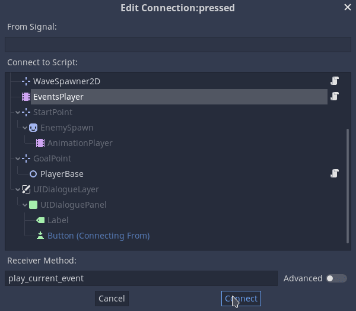

Connect the button’s `pressed` signal to the *UIDialoguePanel*’s `hide` method too. By default, Godot doesn’t allow us to connect signals to nodes that don’t have a script attached. To have all nodes available for connection, toggle the *Advanced* connection mode.

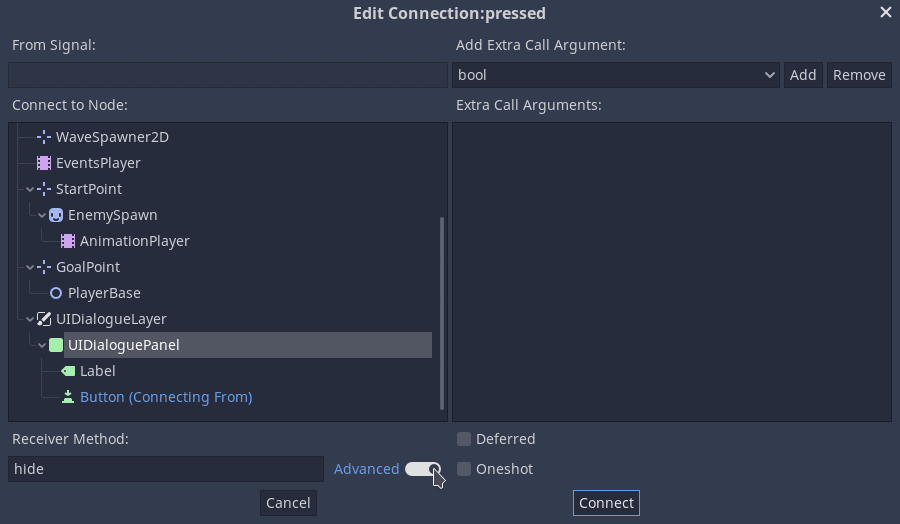

Change the button’s *Text* to something like *Got it!* or *Next!* to communicate what it does to players. This is how our dialogue panel should look like after tweaking the rects and anchors of each element.

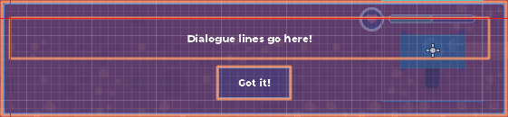

*Note that the Label’s rect doesn’t overlap with the button’s.*

By default, the dialogue panel should be hidden, as we may not want to display it in the plan mode. Toggle off the *UIDialoguePanel > Visibility > Visible* property. Save the scene and let’s start with the creative work!

## Designing new levels

Now that we have the blueprint for our levels, let’s create a new one. Create a new inherited scene based on `res://Levels/Level.tscn` and save it as `res://Levels/Level1.tscn`.

Let’s introduce players to our game using some events!

First, we display some dialogue explaining the context and greeting players. Create a new event and call it `00.welcome`. Using the animation editor, add a key making the *UIDialoguePanel* visible. This should always be the first thing we do when displaying dialogue.

In the *Label*, write something like:

> Hello, welcome to Aster-570, a asteroid full of resources.

And insert a new key to this property. This is how we change the dialogue’s text on every event. Cool, right?

To make the text appear smoothly, we can animate the *Label > Percent Visible* property from `0.0` to `1.0`. Set it to `0.0` and insert a new key in the animation editor. One second should be enough to display this short message. At `1.0` seconds in the animation timeline, duplicate the key we just inserted. You can select it with the left mouse button and press `CTRL` + `D`. Set its value to `1.0` using the *Inspector*.

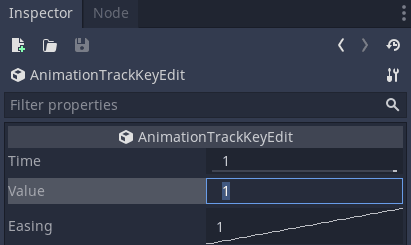

Get used to changing track key values using the *Inspector*, as we use this dialogue as “template” for the next ones. This is how the animation should look like.

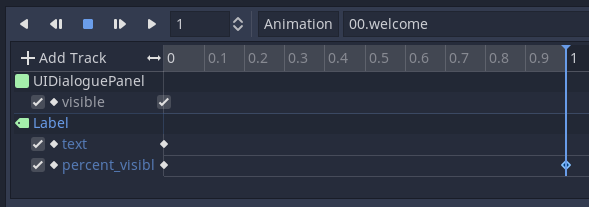

Let’s keep with the introduction and tell the players what to do and what’s their goal.

Using the

[figure not shown]

`Animation` menu, duplicate the `00.welcome` animation and rename it as `01.intro`. Remember to always increment your indexing character to keep your events ordered.

Select the *Label:text* track’s key and change its value to something else using the *Inspector*:

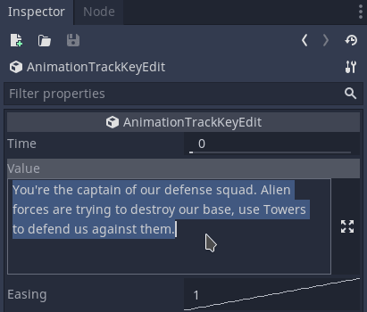

When you’re done with your dialogues, make sure to hide the *UIDialoguePanel* again.

Let’s test these dialogues! Save the scene and hit the *Play Scene* button. You may notice that nothing happens because we made the *Game* tell the level when to start. But, as we’re testing, set the `00.welcome` as *Autoplay*. Remember to toggle that off when you finish testing.

The `00.welcome` event will play twice before the `01.intro` plays. That’s because this is not the correct way to play events. Instead, they should always play through the *EventsPlayer*’s `play_event()` or `play_current_event()` methods. So as soon as we press the button it calls the `play_current_event()` method and everything goes back to normal. As this is a test, we are fine. But don’t use this *Autoplay* approach on production.

We can do lots with this power. For instance, what about highlighting the player’s building to show what players should defend? For that we can animate the *PlayerBase > Modulate* property to make it twinkle. On the next event we set it back to its default white modulate.

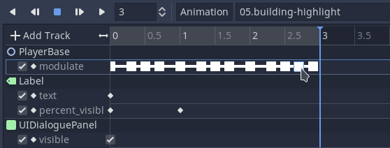

When we finish the events where players have no active roles, we can start the round. This should switch back to plan mode and allow players to make their strategies. Create an event that calls the *Level*’s `start_round()` method using a *Call Method Track*.

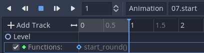

After this event, we start the fun with enemy waves. Do you remember how to do that? We saw it in the *Coding Level Events* lesson.

Create a new event and name it according to when the *EventsPlayer* should play it. If you already have a *Wave* to use, drag the scene file to the *WaveSpawner2D > Spawn Scene* property and insert a key to this property. Then, add a *Call Method Track* with a call that calls the *Level*’s `spawn_wave()` method.

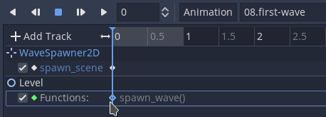

Just like we used the `00.welcome` as template for dialogues, we can use this one as template to spawn new waves. We change the `spawn_scene` track’s key using the *Inspector* and drag new wave scenes as its value.

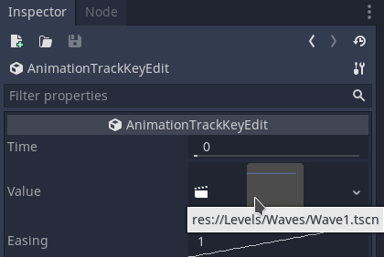

From here, you can use your imagination to create new and interesting events. For instance, what about a dialogue introducing the *Tough Enemy* before it appears? Or a congratulations message before the level finishes? You can use an event to call the *Level*’s `finish()` method for that.